# Regularization for regression (lab 6 for BIOS 26122)

Author

Dmitry Kondrashov

## Description

The goal of this assignment is to learn to use and understand regularization methods for multivariate linear regression, such as ridge and LASSO.

The use of these models is demonstrated in the week 6 tutorials using the tools from package `tidymodels`; I recommend that you use them to perform the tasks below.

The data set `fat` loaded below from the package `faraway` contains variables age, weight, height, and 10 body circumference measurements measured for 252 men. There are four potential response variables `brozek`, `free`, `siri`, and `density`, which are all highly related measures of body fat percentage.

```r
data("fat")
glimpse(fat)
```

```
Rows: 252
Columns: 18
$ brozek  <dbl> 12.6, 6.9, 24.6, 10.9, 27.8, 20.6, 19.0, 12.8, 5.1, 12.0, 7.5,…
$ siri    <dbl> 12.3, 6.1, 25.3, 10.4, 28.7, 20.9, 19.2, 12.4, 4.1, 11.7, 7.1,…
$ density <dbl> 1.0708, 1.0853, 1.0414, 1.0751, 1.0340, 1.0502, 1.0549, 1.0704…
$ age     <int> 23, 22, 22, 26, 24, 24, 26, 25, 25, 23, 26, 27, 32, 30, 35, 35…
$ weight  <dbl> 154.25, 173.25, 154.00, 184.75, 184.25, 210.25, 181.00, 176.00…
$ height  <dbl> 67.75, 72.25, 66.25, 72.25, 71.25, 74.75, 69.75, 72.50, 74.00,…
$ adipos  <dbl> 23.7, 23.4, 24.7, 24.9, 25.6, 26.5, 26.2, 23.6, 24.6, 25.8, 23…
$ free    <dbl> 134.9, 161.3, 116.0, 164.7, 133.1, 167.0, 146.6, 153.6, 181.3,…
$ neck    <dbl> 36.2, 38.5, 34.0, 37.4, 34.4, 39.0, 36.4, 37.8, 38.1, 42.1, 38…
$ chest   <dbl> 93.1, 93.6, 95.8, 101.8, 97.3, 104.5, 105.1, 99.6, 100.9, 99.6…
$ abdom   <dbl> 85.2, 83.0, 87.9, 86.4, 100.0, 94.4, 90.7, 88.5, 82.5, 88.6, 8…
$ hip     <dbl> 94.5, 98.7, 99.2, 101.2, 101.9, 107.8, 100.3, 97.1, 99.9, 104.…
$ thigh   <dbl> 59.0, 58.7, 59.6, 60.1, 63.2, 66.0, 58.4, 60.0, 62.9, 63.1, 59…
$ knee    <dbl> 37.3, 37.3, 38.9, 37.3, 42.2, 42.0, 38.3, 39.4, 38.3, 41.7, 39…
$ ankle   <dbl> 21.9, 23.4, 24.0, 22.8, 24.0, 25.6, 22.9, 23.2, 23.8, 25.0, 25…
$ biceps  <dbl> 32.0, 30.5, 28.8, 32.4, 32.2, 35.7, 31.9, 30.5, 35.9, 35.6, 32…
$ forearm <dbl> 27.4, 28.9, 25.2, 29.4, 27.7, 30.6, 27.8, 29.0, 31.1, 30.0, 29…
$ wrist   <dbl> 17.1, 18.2, 16.6, 18.2, 17.7, 18.8, 17.7, 18.8, 18.2, 19.2, 18…
```

## Multivariate regression

1. First, clean the data to keep only `brozek` of the above response variables and remove any missing values. Second, split the data into training and test sets. Third, perform standard linear regression using `lm` on the training set using `brozek` as the response variable and report which of the predictor variables have the most significant relationship with it.

```r
fat_clean <- fat |>
 dplyr::select(-c(siri, density, free)) |>
 drop_na()


# Put 3/4 of the data into the training set
fat_split <- initial_split(fat_clean, prop = 0.75)

# Create data frames for the two sets:
fat_train <- training(fat_split)
fat_test  <- testing(fat_split)

fat_recipe <-
  recipe(brozek ~ ., data = fat_train)

lm_spec <- linear_reg() |>
  set_mode("regression") |>
  set_engine("lm")

workflow_lm <- workflow() |>
  add_model(lm_spec) |>
  add_recipe(fat_recipe)

fit_lm <- workflow_lm |>
  fit(fat_train)

tidy(fit_lm)
```

```
# A tibble: 15 × 5
   term        estimate std.error statistic  p.value
   <chr>          <dbl>     <dbl>     <dbl>    <dbl>
 1 (Intercept) -56.9      44.0      -1.29   1.98e- 1
 2 age           0.0692    0.0354    1.96   5.22e- 2
 3 weight       -0.213     0.121    -1.76   7.95e- 2
 4 height        0.432     0.652     0.663  5.08e- 1
 5 adipos        0.672     0.956     0.703  4.83e- 1
 6 neck         -0.504     0.252    -2.00   4.71e- 2
 7 chest         0.0221    0.117     0.189  8.50e- 1
 8 abdom         0.864     0.102     8.48   9.21e-15
 9 hip          -0.0962    0.170    -0.566  5.72e- 1
10 thigh         0.301     0.163     1.85   6.55e- 2
11 knee          0.0236    0.270     0.0874 9.30e- 1
12 ankle         0.136     0.226     0.601  5.48e- 1
13 biceps        0.203     0.198     1.02   3.08e- 1
14 forearm       0.565     0.318     1.78   7.71e- 2
15 wrist        -1.91      0.646    -2.96   3.49e- 3
```

```r
# You can also use lm
lm_out <- lm(brozek ~ ., data = fat_train)
summary(lm_out)
```

```
Call:
lm(formula = brozek ~ ., data = fat_train)

Residuals:
     Min       1Q   Median       3Q      Max
-10.3294  -2.6616   0.0019   2.9818   9.3791

Coefficients:
             Estimate Std. Error t value Pr(>|t|)
(Intercept) -56.89566   44.01064  -1.293  0.19780
age           0.06917    0.03538   1.955  0.05218 .
weight       -0.21334    0.12093  -1.764  0.07946 .
height        0.43243    0.65189   0.663  0.50798
adipos        0.67226    0.95608   0.703  0.48291
neck         -0.50409    0.25206  -2.000  0.04707 *
chest         0.02208    0.11676   0.189  0.85021
abdom         0.86370    0.10181   8.483 9.21e-15 ***
hip          -0.09620    0.17004  -0.566  0.57228
thigh         0.30117    0.16250   1.853  0.06553 .
knee          0.02360    0.26995   0.087  0.93043
ankle         0.13604    0.22622   0.601  0.54838
biceps        0.20292    0.19838   1.023  0.30776
forearm       0.56501    0.31770   1.778  0.07707 .
wrist        -1.91161    0.64557  -2.961  0.00349 **
---
Signif. codes:  0 '***' 0.001 '**' 0.01 '*' 0.05 '.' 0.1 ' ' 1

Residual standard error: 4.053 on 174 degrees of freedom
Multiple R-squared:  0.7495,    Adjusted R-squared:  0.7293
F-statistic: 37.18 on 14 and 174 DF,  p-value: < 2.2e-16
```

2. Calculate the r squared of the predictions on the test set and report them. How does it compare to the r-squared from the summary of lm? Do you see evidence of overfitting?

```r
compare_pred <- augment(fit_lm, new_data = fat_test)

compare_pred |> rsq(brozek, .pred)
```

```
# A tibble: 1 × 3
  .metric .estimator .estimate
  <chr>   <chr>          <dbl>
1 rsq     standard       0.662
```

## Ridge regression

3. Perform ridge regression on the training set using a couple of different values of penalty lambda and report the parameter values and the r-squared on the test set.

```r
ridge_spec <- linear_reg(mixture = 0, penalty= 0.1) |>
  set_mode("regression") |>
  set_engine("glmnet")

workflow_ridge <- workflow() |>
  add_model(ridge_spec) |>
  add_recipe(fat_recipe)

fit_ridge <- workflow_ridge |>
  fit(fat_train)

print("The parameters and r-squared of the prediction on the test with lambda = 0.1:")
```

```
[1] "The parameters and r-squared of the prediction on the test with lambda = 0.1:"
```

```r
tidy(fit_ridge)
```

```
# A tibble: 15 × 3
   term        estimate penalty
   <chr>          <dbl>   <dbl>
 1 (Intercept)  -2.07       0.1
 2 age           0.100      0.1
 3 weight       -0.0159     0.1
 4 height       -0.253      0.1
 5 adipos        0.170      0.1
 6 neck         -0.402      0.1
 7 chest         0.113      0.1
 8 abdom         0.465      0.1
 9 hip           0.0141     0.1
10 thigh         0.195      0.1
11 knee          0.0604     0.1
12 ankle        -0.0107     0.1
13 biceps        0.0700     0.1
14 forearm       0.367      0.1
15 wrist        -1.88       0.1
```

```r
compare_pred <- augment(fit_ridge, new_data = fat_test)

compare_pred |> rsq(brozek, .pred)
```

```
# A tibble: 1 × 3
  .metric .estimator .estimate
  <chr>   <chr>          <dbl>
1 rsq     standard       0.712
```

```r
ridge_spec <- linear_reg(mixture = 0, penalty= 1) |>
  set_mode("regression") |>
  set_engine("glmnet")

workflow_ridge <- workflow() |>
  add_model(ridge_spec) |>
  add_recipe(fat_recipe)

fit_ridge <- workflow_ridge |>
  fit(fat_train)

print("The parameters and r-squared of the prediction on the test with lambda = 1:")
```

```
[1] "The parameters and r-squared of the prediction on the test with lambda = 1:"
```

```r
tidy(fit_ridge)
```

```
# A tibble: 15 × 3
   term        estimate penalty
   <chr>          <dbl>   <dbl>
 1 (Intercept) -1.97          1
 2 age          0.0997        1
 3 weight      -0.00507       1
 4 height      -0.276         1
 5 adipos       0.216         1
 6 neck        -0.333         1
 7 chest        0.125         1
 8 abdom        0.383         1
 9 hip          0.0406        1
10 thigh        0.174         1
11 knee         0.0834        1
12 ankle       -0.0405        1
13 biceps       0.0623        1
14 forearm      0.286         1
15 wrist       -1.71          1
```

```r
compare_pred <- augment(fit_ridge, new_data = fat_test)

compare_pred |> rsq(brozek, .pred)
```

```
# A tibble: 1 × 3
  .metric .estimator .estimate
  <chr>   <chr>          <dbl>
1 rsq     standard       0.701
```

4. Perform ridge regression on the training set with parameter tuning, using k-fold validation. Make a plot of the rmse and r-squared as a function of lambda and report the best value of lambda.

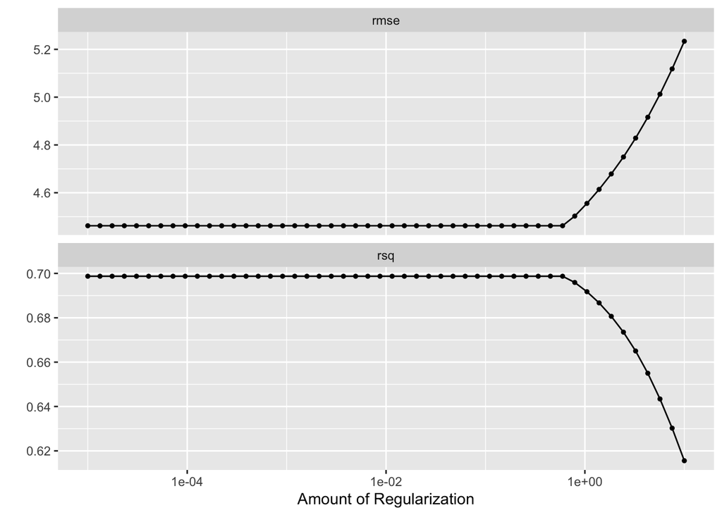

   ```r
   fat_fold <- vfold_cv(fat_train, v = 10)

   ridge_recipe <-
     recipe(brozek~ ., data = fat_train) |>
     step_novel(all_nominal_predictors()) |>
     step_dummy(all_nominal_predictors()) |>
     step_zv(all_predictors()) |>
     step_normalize(all_predictors())

   ridge_spec <-
     linear_reg(penalty= tune(), mixture = 0) |>
     set_mode("regression") |>
     set_engine("glmnet")

   ridge_workflow <- workflow() |>
     add_recipe(ridge_recipe) |>
     add_model(ridge_spec)


   penalty_grid <- grid_regular(penalty(range = c(-5, 1)), levels = 50)


   tune_res <- tune_grid(
     ridge_workflow,
     resamples = fat_fold,
     grid = penalty_grid
   )

   autoplot(tune_res)
   ```

   ```r
   collect_metrics(tune_res)
   ```

   ```
   # A tibble: 100 × 7
        penalty .metric .estimator  mean     n std_err .config
          <dbl> <chr>   <chr>      <dbl> <int>   <dbl> <chr>
    1 0.00001   rmse    standard   4.46     10  0.299  Preprocessor1_Model01
    2 0.00001   rsq     standard   0.699    10  0.0316 Preprocessor1_Model01
    3 0.0000133 rmse    standard   4.46     10  0.299  Preprocessor1_Model02
    4 0.0000133 rsq     standard   0.699    10  0.0316 Preprocessor1_Model02
    5 0.0000176 rmse    standard   4.46     10  0.299  Preprocessor1_Model03
    6 0.0000176 rsq     standard   0.699    10  0.0316 Preprocessor1_Model03
    7 0.0000233 rmse    standard   4.46     10  0.299  Preprocessor1_Model04
    8 0.0000233 rsq     standard   0.699    10  0.0316 Preprocessor1_Model04
    9 0.0000309 rmse    standard   4.46     10  0.299  Preprocessor1_Model05
   10 0.0000309 rsq     standard   0.699    10  0.0316 Preprocessor1_Model05
   # ℹ 90 more rows
   ```

   ```r
   best_penalty<- select_best(tune_res, metric = "rmse")

   best_penalty
   ```

   ```
   # A tibble: 1 × 2
     penalty .config
       <dbl> <chr>
   1 0.00001 Preprocessor1_Model01
   ```

5. Get the final model using the best penalty value, generate predictions on the test set, and report the parameter values and the r-squared on the test set.

```r
ridge_final <- finalize_workflow(ridge_workflow, best_penalty)

ridge_final_fit <- fit(ridge_final, data = fat_train)

augment(ridge_final_fit, new_data = fat_test) |>
  rsq(truth = brozek, estimate = .pred)
```

```
# A tibble: 1 × 3
  .metric .estimator .estimate
  <chr>   <chr>          <dbl>
1 rsq     standard       0.712
```

```r
tidy(ridge_final_fit, penalty= best_penalty$penalty)
```

```
# A tibble: 15 × 3
   term        estimate penalty
   <chr>          <dbl>   <dbl>
 1 (Intercept)  18.8    0.00001
 2 age           1.27   0.00001
 3 weight       -0.486  0.00001
 4 height       -0.694  0.00001
 5 adipos        0.623  0.00001
 6 neck         -0.995  0.00001
 7 chest         0.950  0.00001
 8 abdom         5.02   0.00001
 9 hip           0.104  0.00001
10 thigh         1.05   0.00001
11 knee          0.154  0.00001
12 ankle        -0.0193 0.00001
13 biceps        0.216  0.00001
14 forearm       0.691  0.00001
15 wrist        -1.70   0.00001
```

6. Compare on the performance of ridge regression to plain linear regression in terms of tuning the parameter lambda and the impact it has on the prediction quality on the test set.

## Regression with LASSO

7. Perform LASSO regression on the training set using a couple of different values of penalty lambda and report the parameter values and the r-squared on the test set.

```r
lasso_spec <- linear_reg(mixture = 1, penalty= 0.1) |>
  set_mode("regression") |>
  set_engine("glmnet")

workflow_ridge <- workflow() |>
  add_model(lasso_spec) |>
  add_recipe(fat_recipe)

fit_ridge <- workflow_ridge |>
  fit(fat_train)

print("The parameters and r-squared of the LASSO prediction on the test with lambda = 0.1:")
```

```
[1] "The parameters and r-squared of the LASSO prediction on the test with lambda = 0.1:"
```

```r
tidy(fit_ridge)
```

```
# A tibble: 15 × 3
   term        estimate penalty
   <chr>          <dbl>   <dbl>
 1 (Intercept)  -0.397      0.1
 2 age           0.0618     0.1
 3 weight       -0.0288     0.1
 4 height       -0.241      0.1
 5 adipos        0          0.1
 6 neck         -0.427      0.1
 7 chest         0          0.1
 8 abdom         0.723      0.1
 9 hip           0          0.1
10 thigh         0.0724     0.1
11 knee          0          0.1
12 ankle         0          0.1
13 biceps        0.0471     0.1
14 forearm       0.510      0.1
15 wrist        -1.79       0.1
```

```r
compare_pred <- augment(fit_ridge, new_data = fat_test)

compare_pred |> rsq(brozek, .pred)
```

```
# A tibble: 1 × 3
  .metric .estimator .estimate
  <chr>   <chr>          <dbl>
1 rsq     standard       0.741
```

```r
lasso_spec <- linear_reg(mixture = 1, penalty= 1) |>
  set_mode("regression") |>
  set_engine("glmnet")

workflow_ridge <- workflow() |>
  add_model(lasso_spec) |>
  add_recipe(fat_recipe)

fit_ridge <- workflow_ridge |>
  fit(fat_train)

print("The parameters and r-squared of the LASSO prediction on the test set with lambda = 1:")
```

```
[1] "The parameters and r-squared of the LASSO prediction on the test set with lambda = 1:"
```

```r
tidy(fit_ridge)
```

```
# A tibble: 15 × 3
   term        estimate penalty
   <chr>          <dbl>   <dbl>
 1 (Intercept)  -19.2         1
 2 age            0           1
 3 weight         0           1
 4 height        -0.107       1
 5 adipos         0           1
 6 neck           0           1
 7 chest          0           1
 8 abdom          0.493       1
 9 hip            0           1
10 thigh          0           1
11 knee           0           1
12 ankle          0           1
13 biceps         0           1
14 forearm        0           1
15 wrist          0           1
```

```r
compare_pred <- augment(fit_ridge, new_data = fat_test)

compare_pred |> rsq(brozek, .pred)
```

```
# A tibble: 1 × 3
  .metric .estimator .estimate
  <chr>   <chr>          <dbl>
1 rsq     standard       0.734
```

8. Perform LASSO regression on the training set with parameter tuning, using k-fold validation. Make a plot of the rmse and r-squared as a function of lambda and report the best value of lambda.

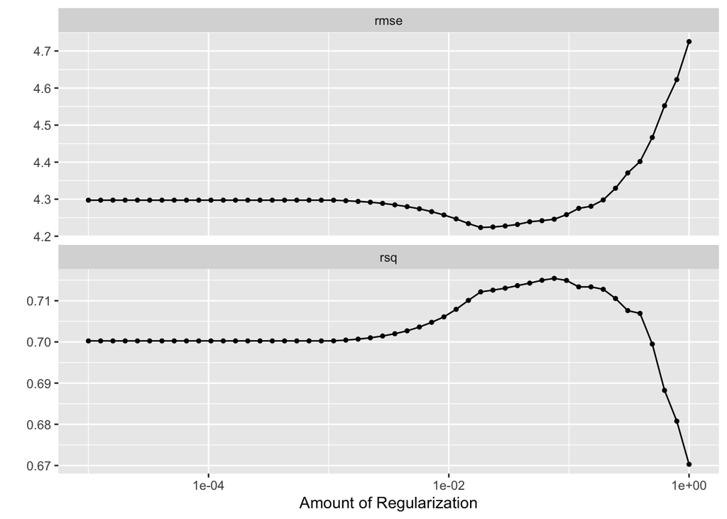

   ```r
   fat_fold <- vfold_cv(fat_train, v = 10)

   lasso_recipe <-
     recipe(brozek~ ., data = fat_train) |>
     step_novel(all_nominal_predictors()) |>
     step_dummy(all_nominal_predictors()) |>
     step_zv(all_predictors()) |>
     step_normalize(all_predictors())

   lasso_spec <-
     linear_reg(penalty= tune(), mixture = 1) |>
     set_mode("regression") |>
     set_engine("glmnet")

   lasso_workflow <- workflow() |>
     add_recipe(lasso_recipe) |>
     add_model(lasso_spec)


   penalty_grid <- grid_regular(penalty(range = c(-5, 0)), levels = 50)


   tune_res <- tune_grid(
     lasso_workflow,
     resamples = fat_fold,
     grid = penalty_grid
   )

   autoplot(tune_res)
   ```

   ```r
   collect_metrics(tune_res)
   ```

   ```
   # A tibble: 100 × 7
        penalty .metric .estimator  mean     n std_err .config
          <dbl> <chr>   <chr>      <dbl> <int>   <dbl> <chr>
    1 0.00001   rmse    standard   4.30     10  0.214  Preprocessor1_Model01
    2 0.00001   rsq     standard   0.700    10  0.0316 Preprocessor1_Model01
    3 0.0000126 rmse    standard   4.30     10  0.214  Preprocessor1_Model02
    4 0.0000126 rsq     standard   0.700    10  0.0316 Preprocessor1_Model02
    5 0.0000160 rmse    standard   4.30     10  0.214  Preprocessor1_Model03
    6 0.0000160 rsq     standard   0.700    10  0.0316 Preprocessor1_Model03
    7 0.0000202 rmse    standard   4.30     10  0.214  Preprocessor1_Model04
    8 0.0000202 rsq     standard   0.700    10  0.0316 Preprocessor1_Model04
    9 0.0000256 rmse    standard   4.30     10  0.214  Preprocessor1_Model05
   10 0.0000256 rsq     standard   0.700    10  0.0316 Preprocessor1_Model05
   # ℹ 90 more rows
   ```

   ```r
   best_penalty<- select_best(tune_res, metric = "rmse")

   best_penalty
   ```

   ```
   # A tibble: 1 × 2
     penalty .config
       <dbl> <chr>
   1  0.0184 Preprocessor1_Model33
   ```

9. Get the final model using the best penalty value, generate predictions on the test set, and report the parameter values and the r-squared on the test set.

```r
lasso_final <- finalize_workflow(lasso_workflow, best_penalty)

lasso_final_fit <- fit(lasso_final, data = fat_train)

augment(lasso_final_fit , new_data = fat_test) |>
  rsq(truth = brozek, estimate = .pred)
```

```
# A tibble: 1 × 3
  .metric .estimator .estimate
  <chr>   <chr>          <dbl>
1 rsq     standard       0.742
```

```r
tidy(lasso_final_fit, penalty= best_penalty$penalty)
```

```
# A tibble: 15 × 3
   term        estimate penalty
   <chr>          <dbl>   <dbl>
 1 (Intercept)  18.8     0.0184
 2 age           0.839   0.0184
 3 weight       -3.58    0.0184
 4 height       -0.168   0.0184
 5 adipos        0       0.0184
 6 neck         -1.20    0.0184
 7 chest         0.0838  0.0184
 8 abdom         9.29    0.0184
 9 hip          -0.320   0.0184
10 thigh         1.32    0.0184
11 knee          0       0.0184
12 ankle         0.220   0.0184
13 biceps        0.545   0.0184
14 forearm       1.16    0.0184
15 wrist        -1.68    0.0184
```

10. Comment on the performance of LASSO regression in comparison to ridge, in terms of both prediction quality and the value of the parameter values from the optimally tuned models.

LASSO seems to do consistently better, generating higher r-squared on the test set. IT also gives a simplified model, because several parameter values are set to 0.